# Topic : An Analysis of Food Security in USA - 2021

### Introduction

Although food is the basic human right, many people in the world are living in highly food insecure condition.

According to World Bank, with the pandemic hit, domestic food price inflation increased at least by 5 percent globally. Also, according to the United Nations news, 828 million people were affected by hunger in 2021. It’s important to analyse what factors are affecting food security and take measures to reduce world’s hunger. This the one of the reasons that we were interested to study food security in USA.

Although, there were limitations to our study. Food security is very complex issue, and needs multi-angle, thorough research. We’ve chosen only certain socio-economic variables out of 507 variables.

#### Our team’s research topic is the situation of food security in 2021. We want to know how different demographic and socioeconomic factors relate to food security.

- We are using the Current Population Survey - Food Security Supplement Dec 2021 data provided by the US Census Bureau
- The Dataset contains 507 variables and roughly 120,000 observations

##### The Smart Question we have proposed and hope to answer are

**Specific**: To study the specific pattern shown in the data that affects food security such as states, counties, income level, whether the family uses SNAP, race, immigrant status, work status, education level and many more demographic, socio-economic variables.

**Measurable**: Use EDA techniques to know how significantly different factors contribute to food insecurity.

**Achievable**: Can find variables which are significantly affecting food insecurity and can create models for ensuring food security in households.

**Relevant**: Food being the basic requirement of any human, this study can shed light on what the authorities and we ourselves can do in order to eradicate food insecurity.

**Time-oriented**: Data set for the month of December 2021 is considered for the study so that it can also show the effect of Covid-19 in food security.

*Considering the Questions we are asking, we have decided to select just 11 factors to work on*

*A very significant limitation to our data is that we have trimmed off a lot of observations where either the interview was not taken or not completed. Ideally we should account for these observations somehow, but due to time constraints we aren’t doing that*

```
## 'data.frame':    71472 obs. of  12 variables:
##  $ Id                : Factor w/ 27922 levels "5185410966","8178510165",..: 16600 9378 9378 8472 8472 7861 7861 19375 19375 24604 ...
##  $ States            : Factor w/ 51 levels "1","2","4","5",..: 1 1 1 1 1 1 1 1 1 1 ...
##  $ Family_Size       : Factor w/ 14 levels "1","2","3","4",..: 1 2 2 2 2 2 2 2 2 1 ...
##  $ Household_Income  : Factor w/ 16 levels "1","2","3","4",..: 16 14 14 12 12 13 13 9 9 11 ...
##  $ SNAP              : Factor w/ 5 levels "-3","-2","-1",..: 3 3 3 5 5 3 3 5 5 3 ...
##  $ Ethnicity         : Factor w/ 24 levels "1","2","3","4",..: 1 1 1 1 1 1 1 2 2 1 ...
##  $ Citizenship_status: Factor w/ 5 levels "1","2","3","4",..: 1 1 1 1 1 1 1 1 1 1 ...
##  $ Number_of_Jobs    : Factor w/ 4 levels "-1","2","3","4": 1 1 1 1 1 1 1 1 1 1 ...
##  $ Hours_on_Jobs     : Factor w/ 88 levels "-4","-1","0",..: 67 43 2 43 43 62 43 2 2 2 ...
##  $ Education_Level   : Factor w/ 17 levels "-1","31","32",..: 14 15 1 14 14 10 10 7 10 5 ...
##  $ FoodSecurity_score: Factor w/ 4 levels "1","2","3","4": 1 1 1 1 1 1 1 2 2 1 ...
##  $ PRNMCHLD          : Factor w/ 12 levels "0","1","2","3",..: 1 2 1 1 1 1 1 1 1 1 ...
```

### **Coming to our Response Variable, Food Security**

**High Food Security**: No reported indications of food-access problems or limitations.

**Marginal Food Security**: One or two reported signs, usually anxiety over food availability or scarcity in the home. There is little to no evidence that diets or food intake have changed.

**Low Food Security**: One or two reported signs, usually indicating worry about food scarcity or insufficiency at home. Little to no evidence of dietary or food intake changes.

**Very Low Food Security**: Reports of numerous signs of altered eating habits and decreased food intake.

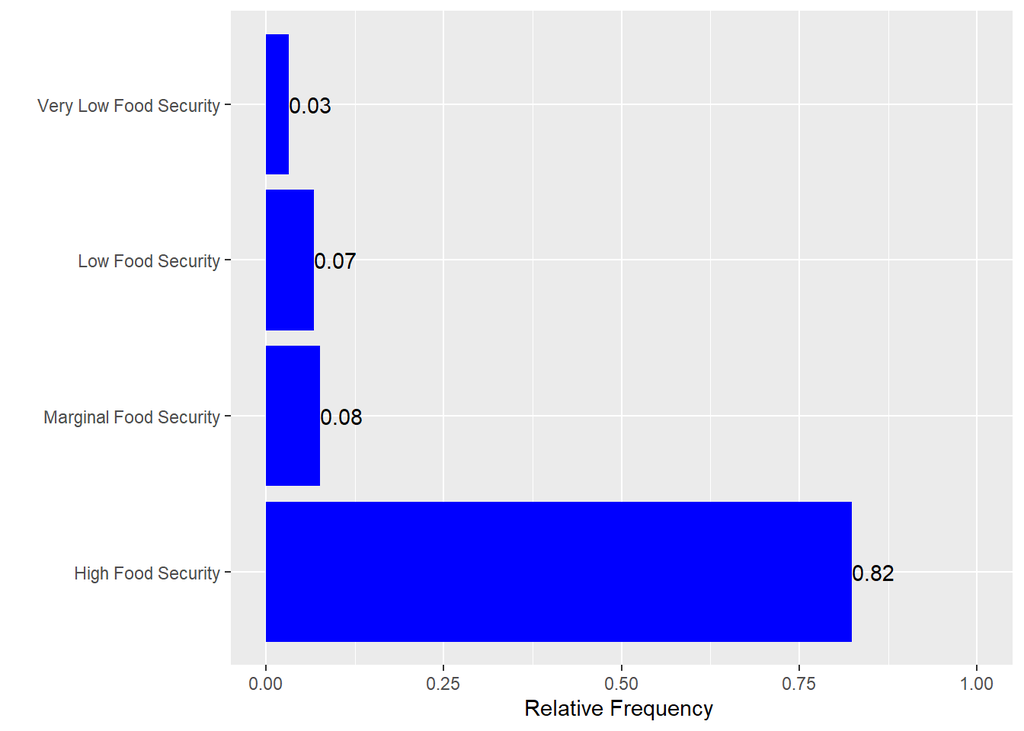

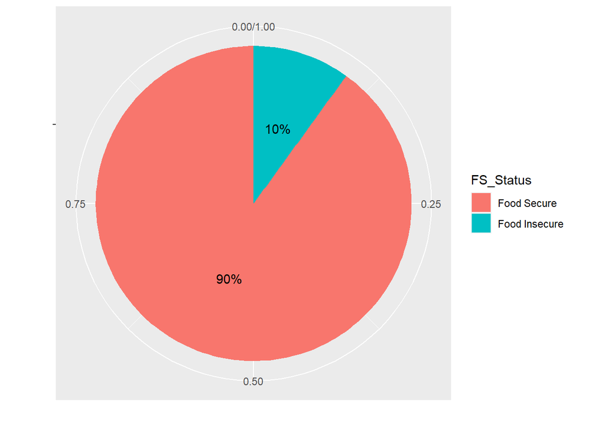

### Ethnicity

##### Plotting barcharts between all types of Ethinicity and food security status

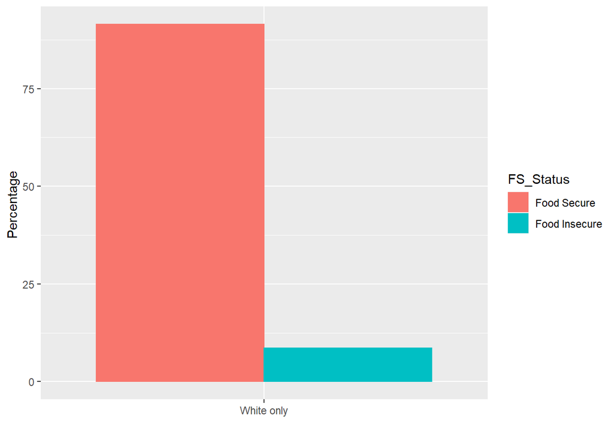

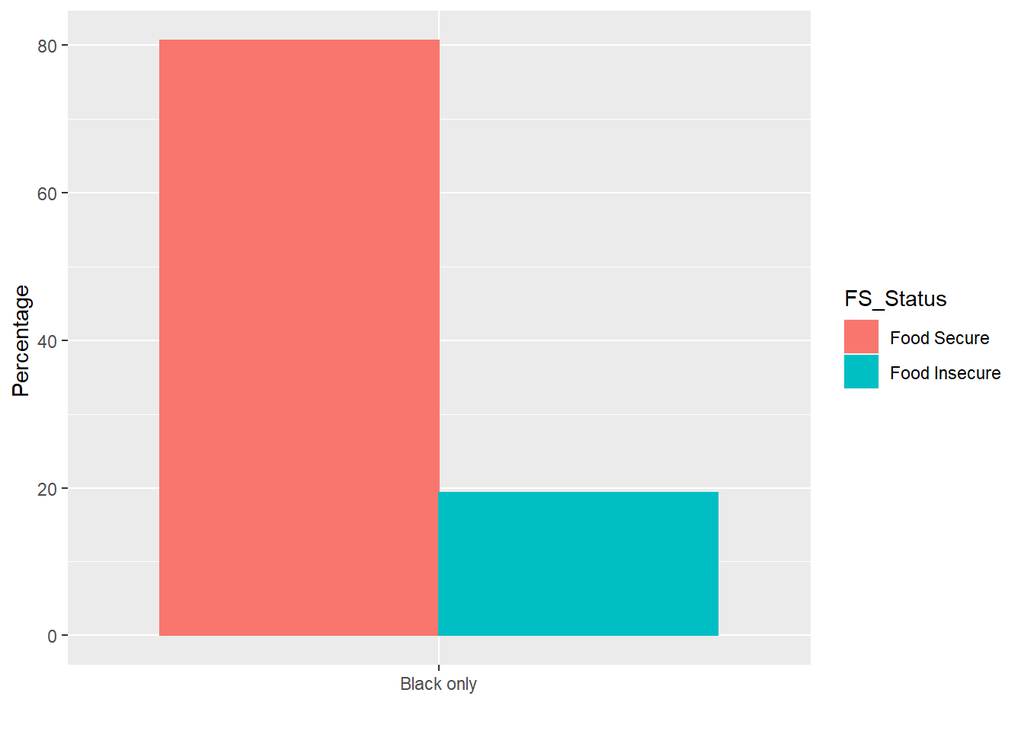

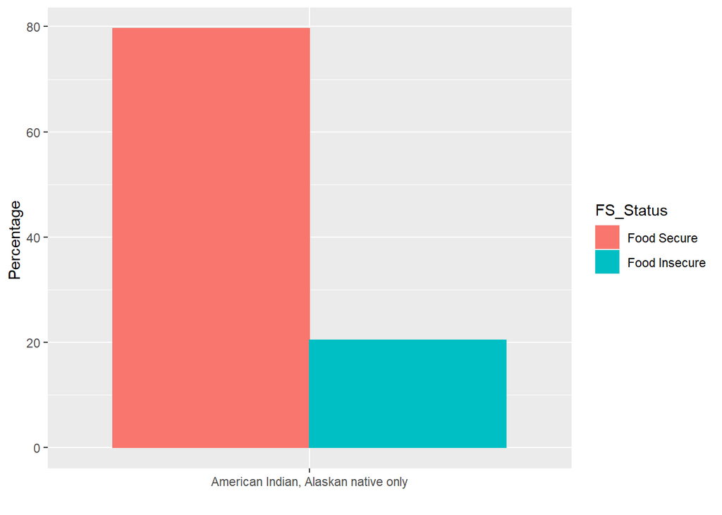

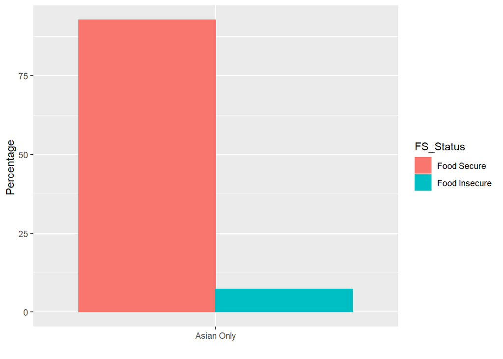

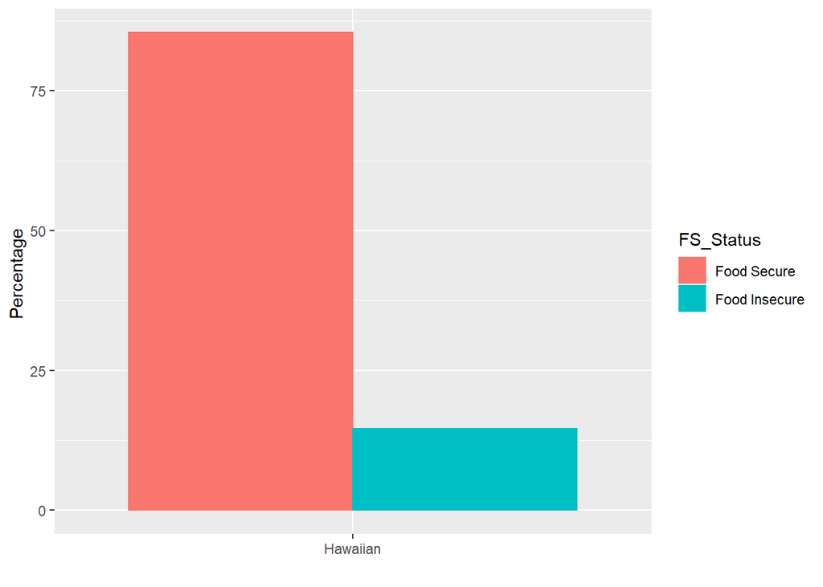

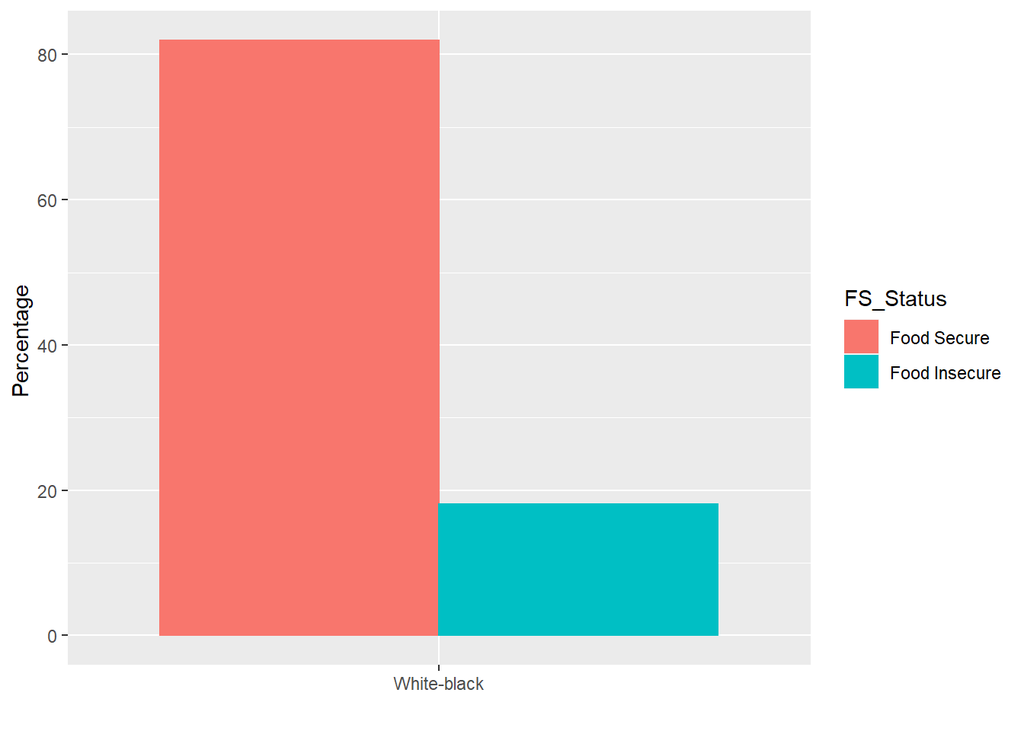

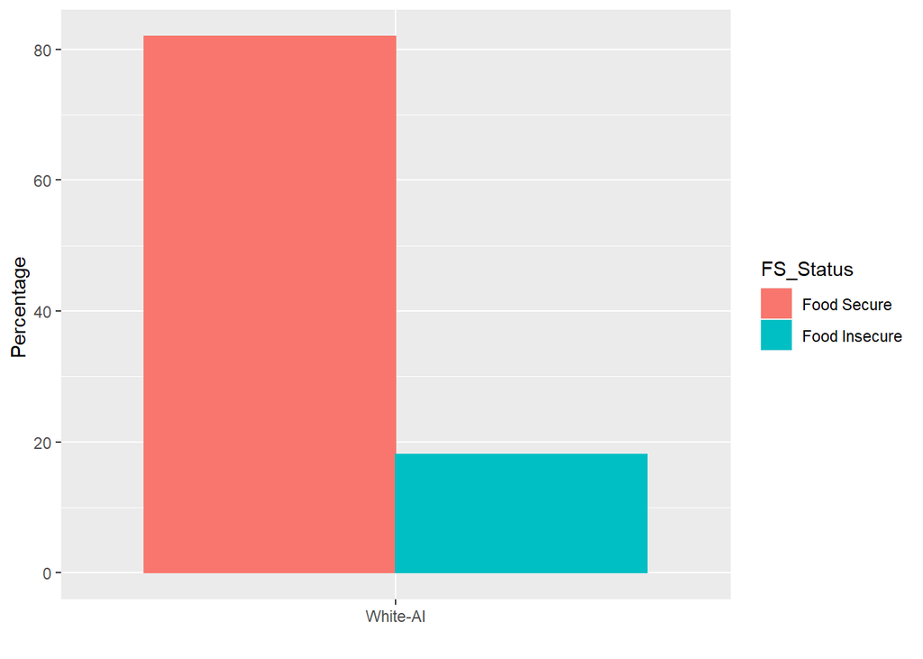

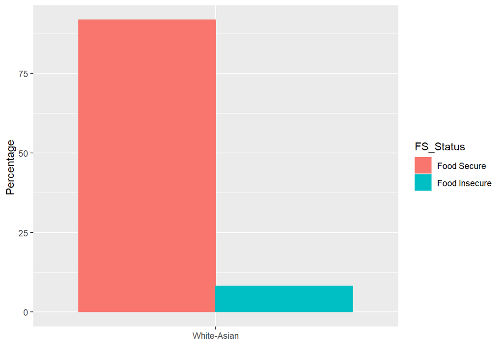

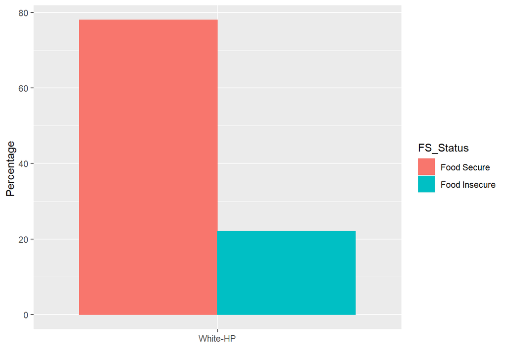

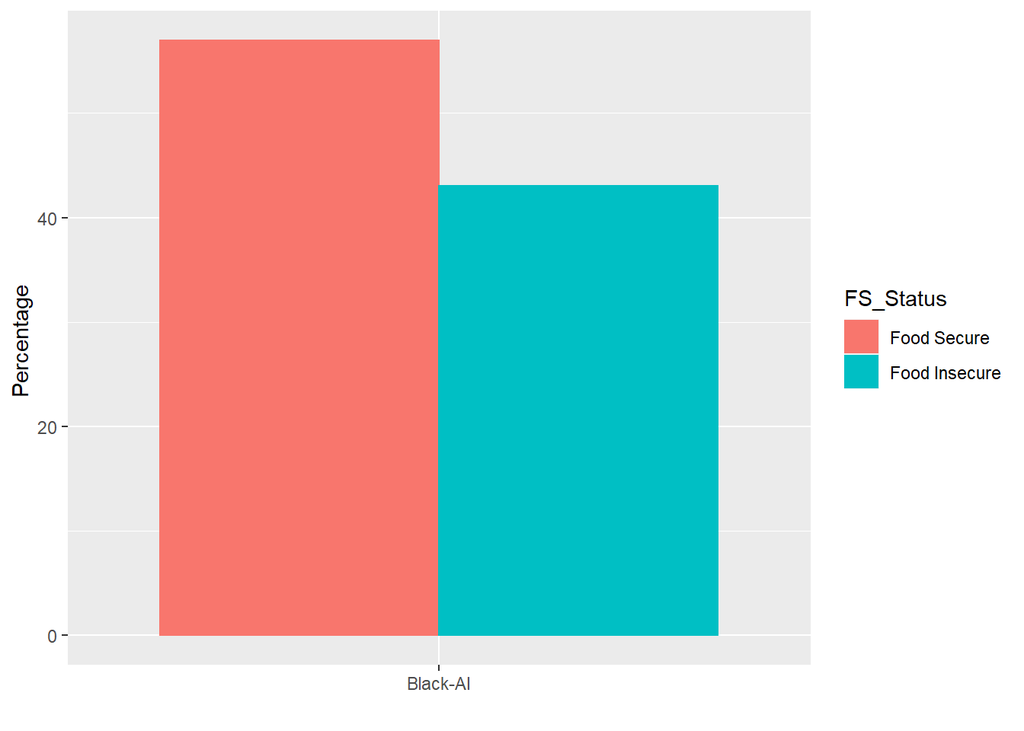

#### Statistical Testing

- We are going to be Using Fisher’s Exact Test instead of Chi-square test because of the numerous levels with low frequency of observations
- Our Null Hypothesis is that Ethnicity and Food Security Status are Independent of each other.
- Taking our alpha to be 5%

```
##
##  Fisher's Exact Test for Count Data with simulated p-value (based on
##  2000 replicates)
##
## data:  FS_Subset$Ethnicity and FS_Subset$FoodSecurity_score
## p-value = 0.0004998
## alternative hypothesis: two.sided
```

*Since, the P-Value is less than our taken alpha we can say that there is a statistically significant relationship between Ethnicity and Food Security

### Citizenship

- We have 5 levels of Citizenship status in this Data. We will explore the relationship between Citizenship and Food Security graphically, and do some statistical testing to confrim the said relationship

##### Plotting barcharts between different Citizenship status’s and food security status

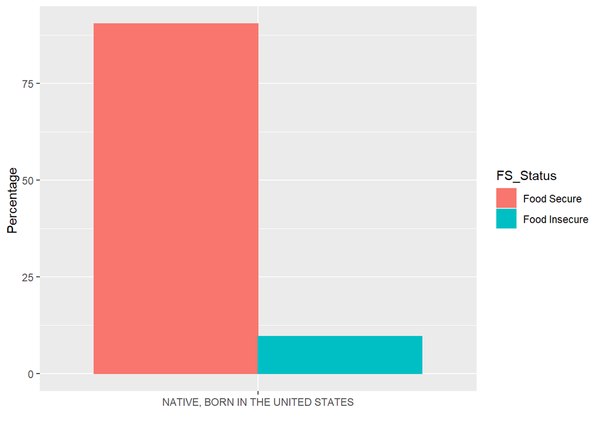

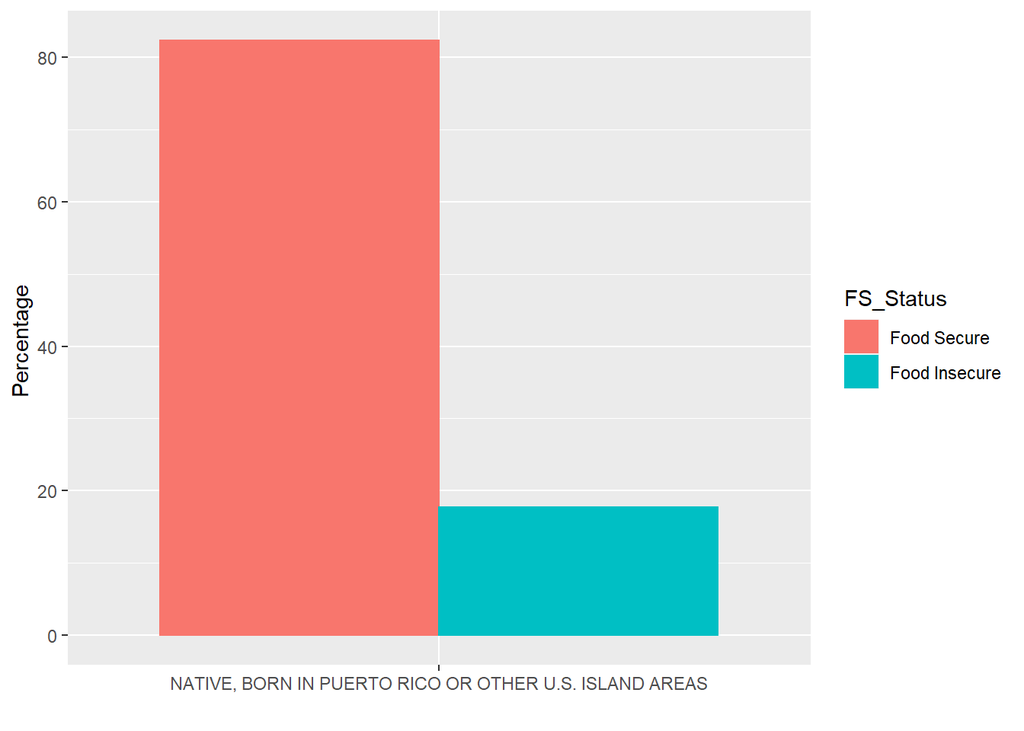

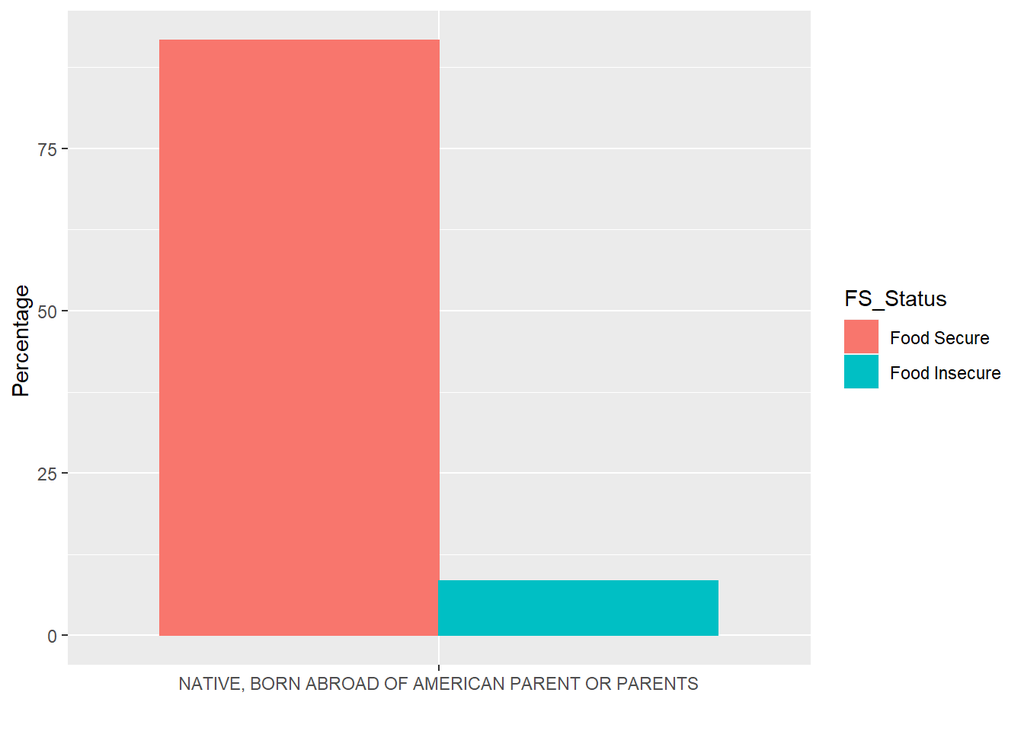

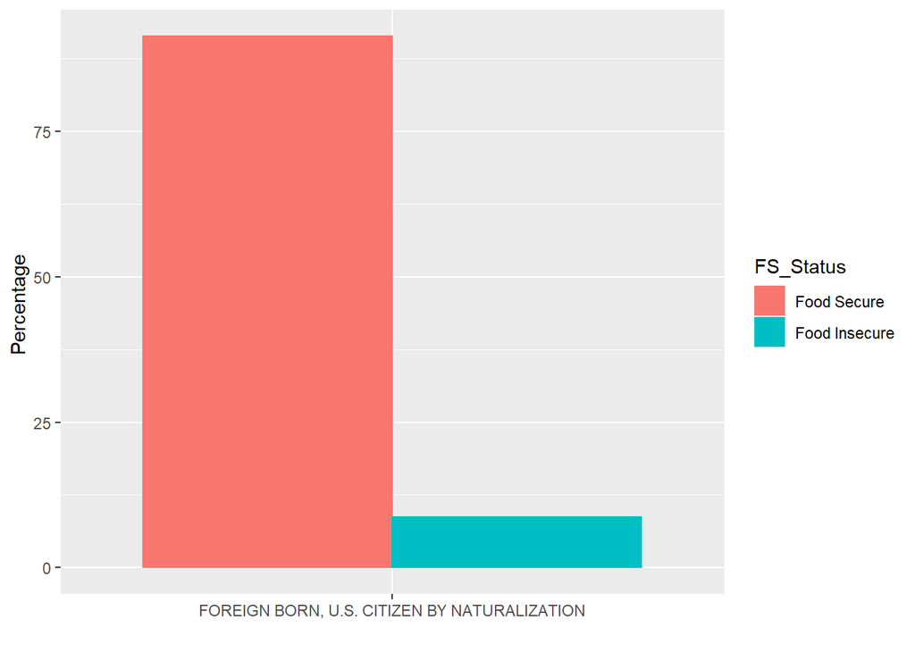

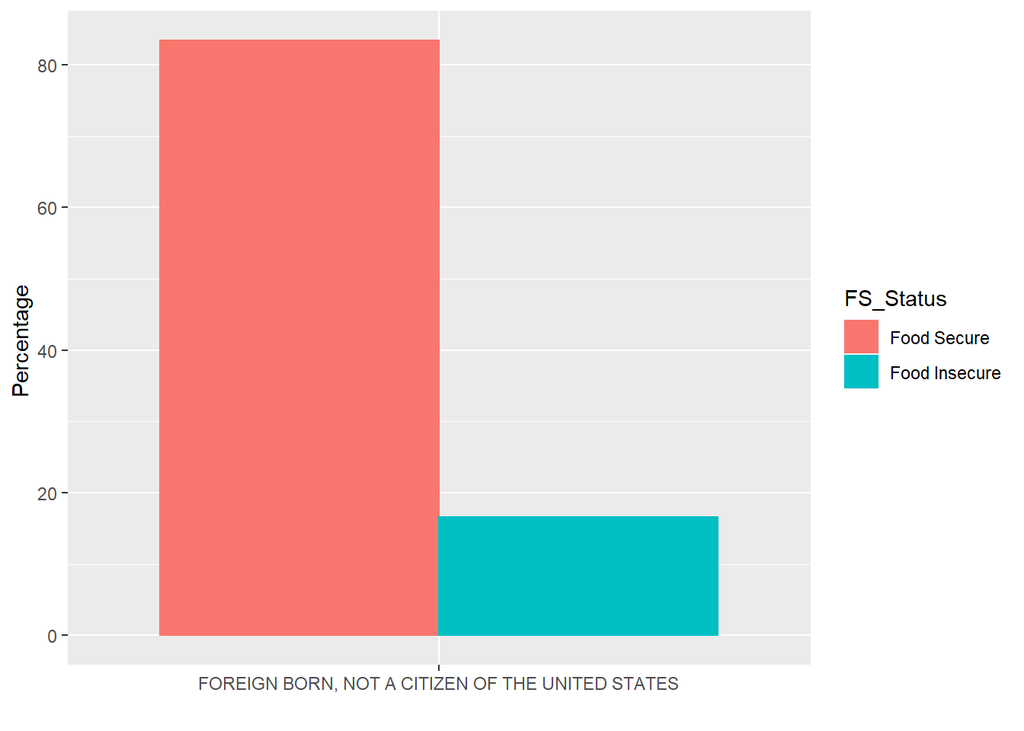

#### Statistical Testing

- We are Chi-square test
- Our Null Hypothesis is that Citizenship Status and Food Security Status are Independent of each other.
- Taking our alpha to be 5%

```
##
##  Pearson's Chi-squared test
##
## data:  FS_Subset$Citizenship_status and FS_Subset$FoodSecurity_score
## X-squared = 437.62, df = 12, p-value < 2.2e-16
```

- Since, the P-Value is less than our taken alpha we can say that there is a statistically significant relationship between Citizenship Status and Food Security

### SNAP

- SNAP Stands for Supplemental Nutrition Assistance Program
- SNAP factor had 5 levels to in this dataset
- We have dropped a level which indicated that the observations are not in universe

##### Plotting Stacked barcharts between SNAP status and food security status

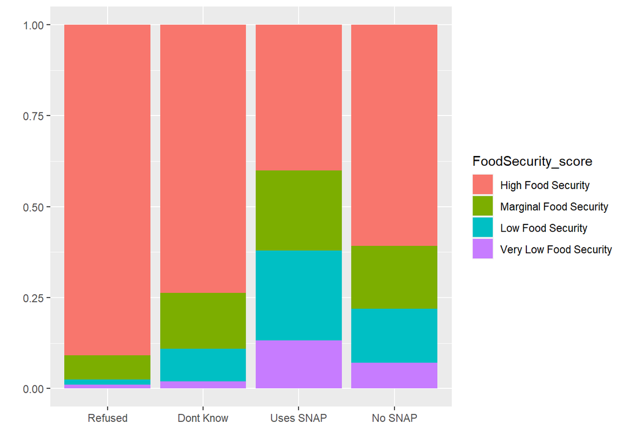

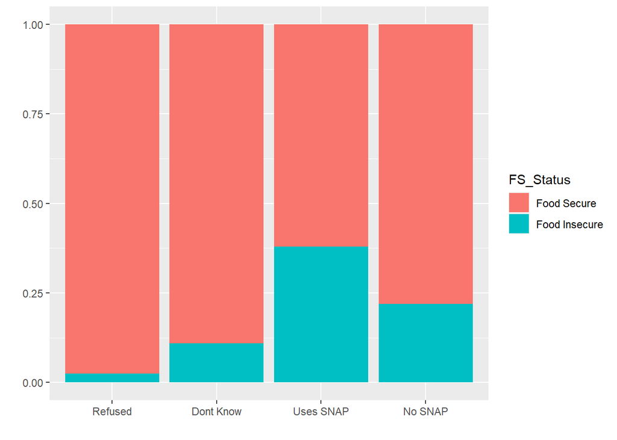

#### Statistical Testing

- We are Chi-square test
- Our Null Hypothesis is that SNAP Status and Food Security Status are Independent of each other.
- Taking our alpha to be 5%

```
##
##  Pearson's Chi-squared test
##
## data:  chi_test_SNAP
## X-squared = 764.1, df = 3, p-value < 2.2e-16
```

- Since, the P-Value is less than our taken alpha we can say that there is a statistically significant relationship between SNAP Status and Food Security

#### Odds Ratio

```
##              Outcome +    Outcome -      Total        Inc risk *        Odds
## Exposed +         4471         2737       7208              62.0        1.63
## Exposed -        14258         4008      18266              78.1        3.56
## Total            18729         6745      25474              73.5        2.78
##
## Point estimates and 95% CIs:
## -------------------------------------------------------------------
## Inc risk ratio                                 0.79 (0.78, 0.81)
## Odds ratio                                     0.46 (0.43, 0.49)
## Attrib risk in the exposed *                   -16.03 (-17.30, -14.76)
## Attrib fraction in the exposed (%)            -25.84 (-28.34, -23.40)
## Attrib risk in the population *                -4.54 (-5.34, -3.73)
## Attrib fraction in the population (%)         -6.17 (-6.68, -5.66)
## -------------------------------------------------------------------
## Uncorrected chi2 test that OR = 1: chi2(1) = 682.162 Pr>chi2 = <0.001
## Fisher exact test that OR = 1: Pr>chi2 = <0.001
##  Wald confidence limits
##  CI: confidence interval
##  * Outcomes per 100 population units
```

- The Odds ratio is 0.46, with a 95% Confidence Interval
- This means that the odds of a person not on SNAP to be food secure is 2.17 times the odds of person on SNAP to be food secure.

### Number of Jobs

Now we conduct an in-depth EDA on the **Number of Jobs of the respondents**

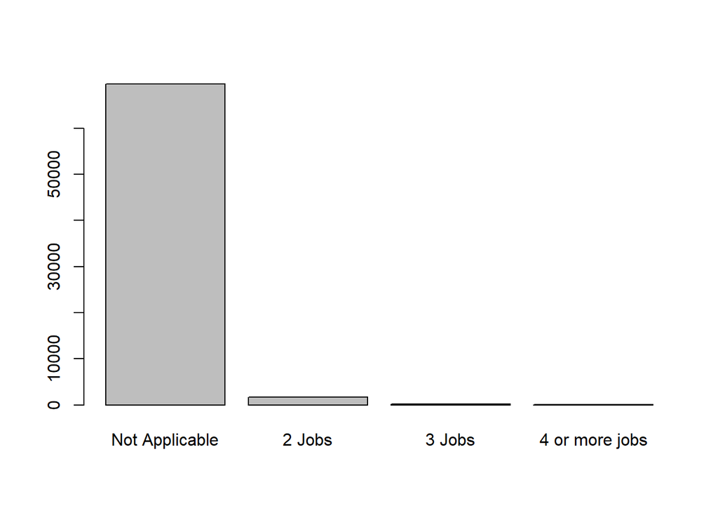

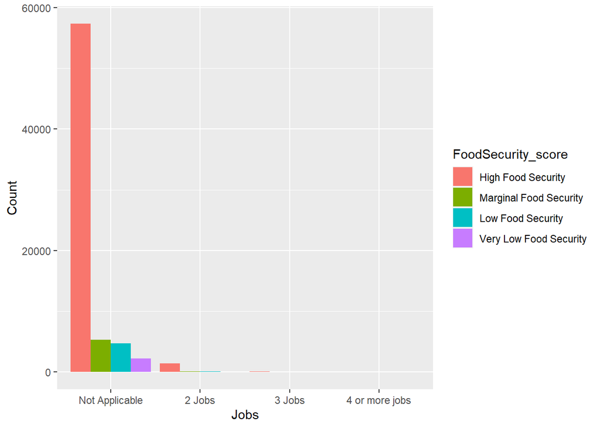

The above graph shows a result where majority of the respondents doesn’t fall under the category of eligible to answer this question. And hence their response is marked as **Not Applicable**.

This hides the proper analysis of the responses. Hence we remove the Not Applicable responses from the variable and move forward with the study.

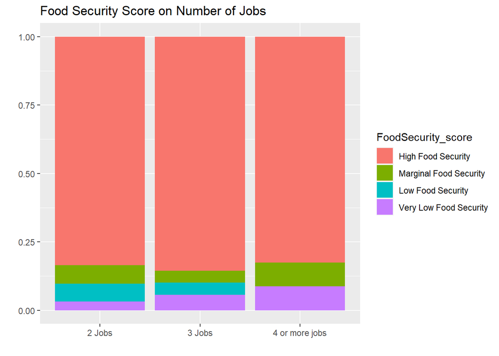

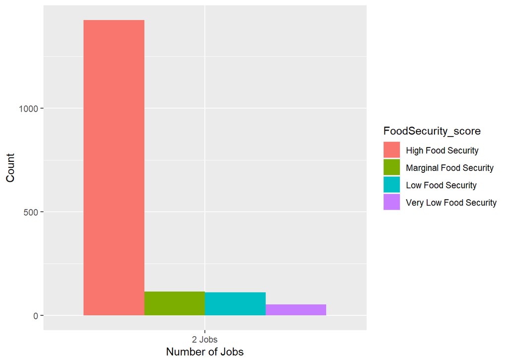

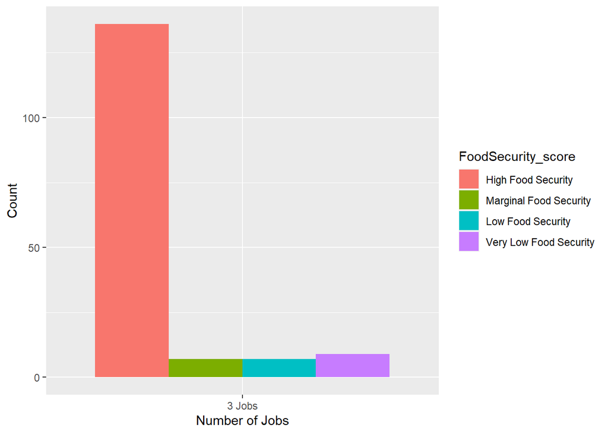

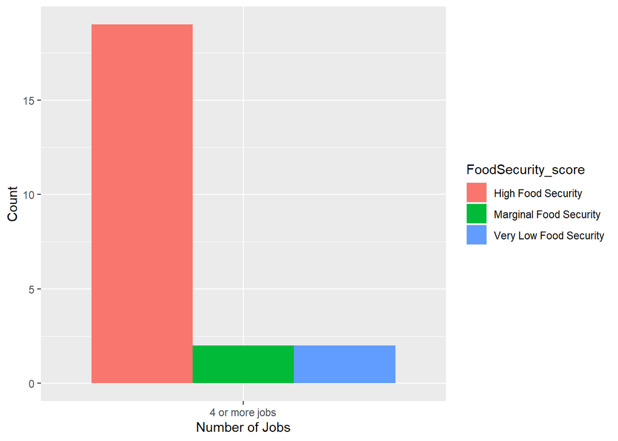

The above graphs clearly gives us an understanding about how many people in different categories of the variable have different food security scores.

Though it is evident that the majority of the responses irrespective of the number of jobs are saying they are Highly Food Secure, people who have 4 or more jobs have a very evident number of food insecure people. But still whether they have any dependency or not needs to be analyzed using proper statistical tests. For this we bring in the Chi- square test.

```
##
##  Pearson's Chi-squared test
##
## data:  contable_number_of_jobs
## X-squared = 8.4874, df = 6, p-value = 0.2045
```

The test showed that, though there is variance in the proportion in graph, there is no dependency of these two vaiables.

### Education Level

The level of education is very important. We always assume that education is a powerful tool to eradicate poverty and hunger. With the assumption that this is true in case for food security, we shall dive into the EDA analysis of the variable. The variable had many responses.

Since the responses were in many categories, it is good to look into their frequency table.

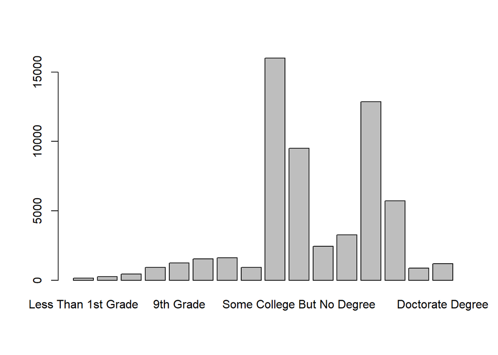

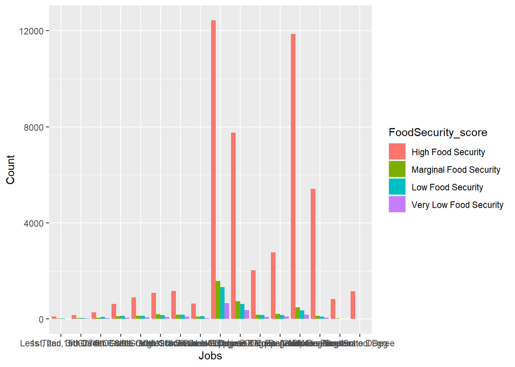

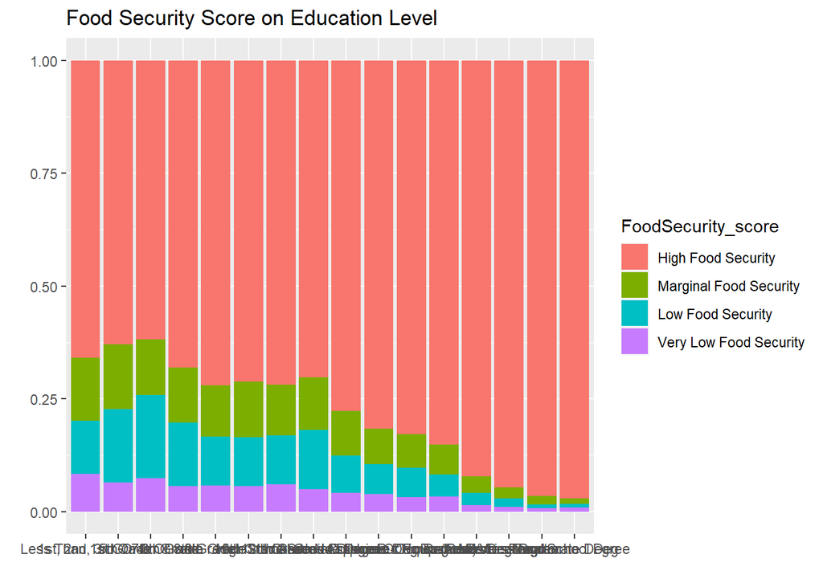

These three graphs gives us a perfect picture of the sample in this variable. Initial graph shows the fact that major proportion of the population belongs to a category of High school education or more. The next two graphs shows us the division of the category in terms of food security score. Though major ratio goes for high food security, we can clearly see a picture of decreasing low food security scored people as the education level increase.

But this hypothesis needs to be supported by appropriate statistical tests. Since the data variables under study are both catgorical, we use Chi-Square test to test the independence of the variables.

The Chi-Square test results are as follows:

```
##
##  Pearson's Chi-squared test
##
## data:  contable_edu
## X-squared = 3136.8, df = 48, p-value < 2.2e-16
```

The test results showed that p-value is less than 0.05, the default alpha value and hence we can say that `Education_Level` is having a significant effect on the Food Security of People. This is such an important factor to keep in mind as giving people more education can actually act as a solution gives us with a better hope. Majority of the population being educated or will be educated makes this variable as important as anything.

### Hours on Job

The Hours on Job for a week vary from people to people. How they food security score had an effect on hours on job is studied in the following EDA analysis.

There were few people who gave response as time varies and they don’t have a perfect time period, gave responses in the study. But inorder to meet the hypothesis of the test and easy analysis, those responses were removed. Removing those responses made the variable continuous and the acceptable range of responses were 0 to 99.

```
## [1] 2
```

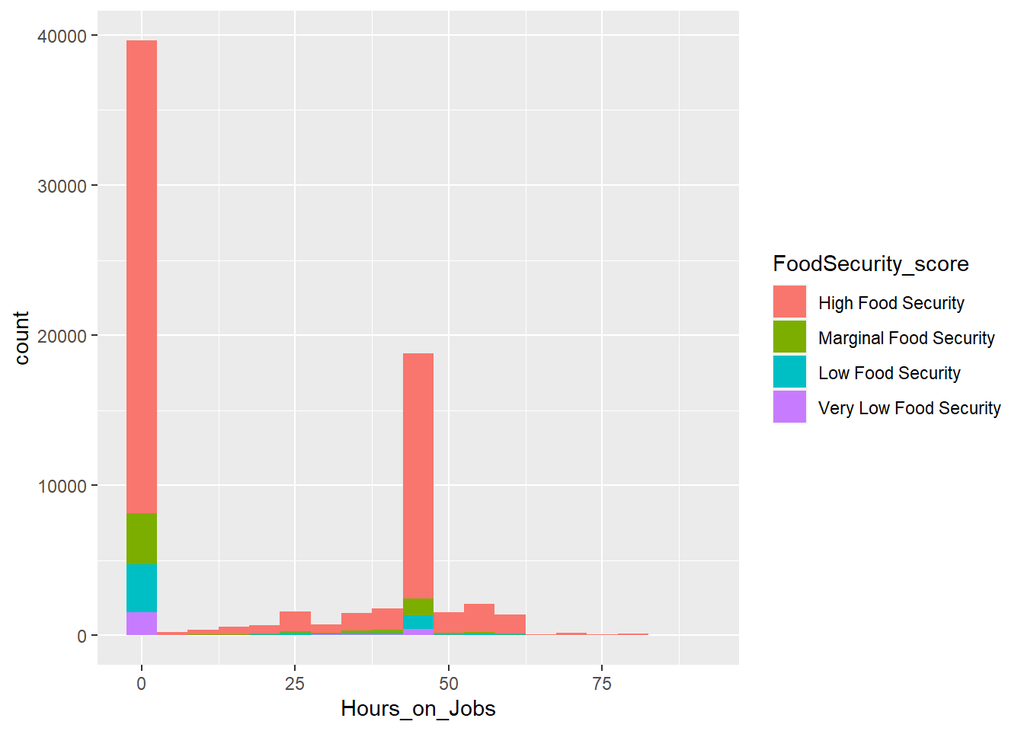

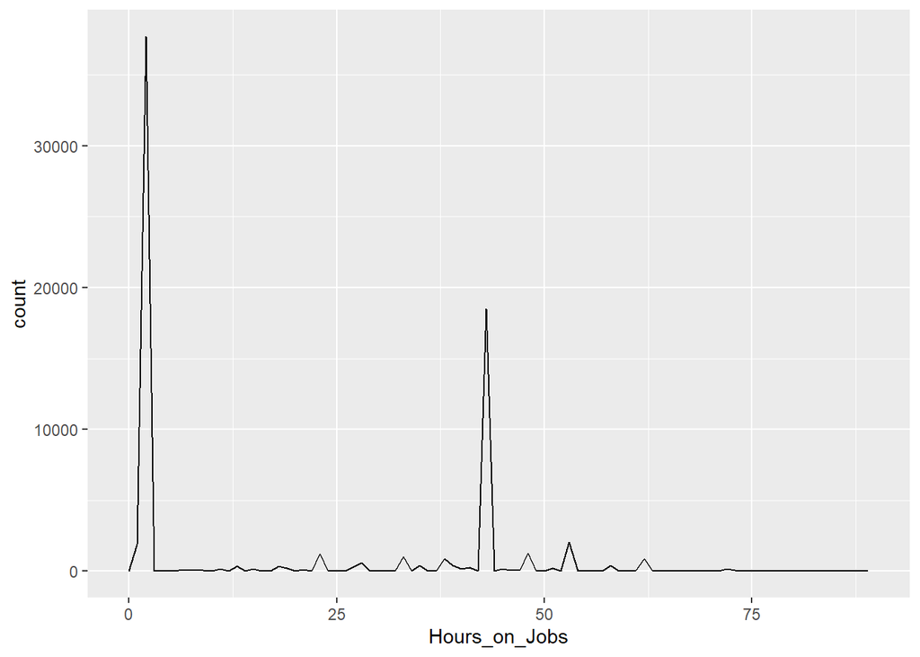

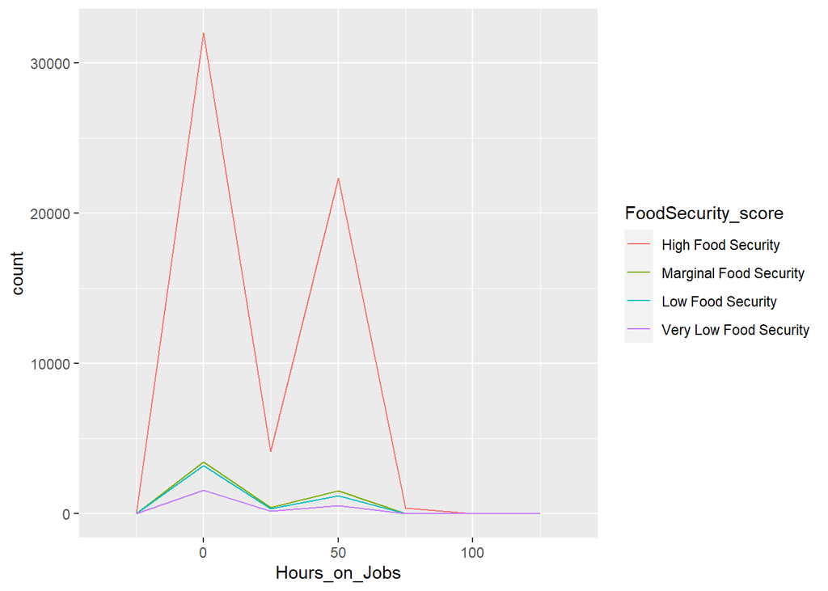

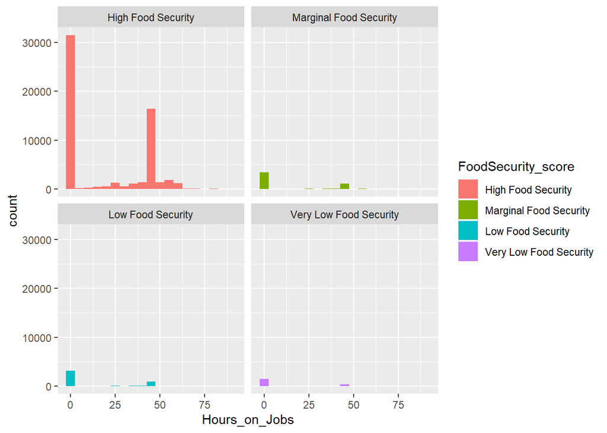

The above graphs clearly depicts the distribution of data on this variable.